# Exploring the BRFSS data

## Setup

### Load packages

```r
library(ggplot2)
library(dplyr)
```

### Load data

Make sure your data and R Markdown files are in the same directory. When loaded your data file will be called `brfss2013`. Delete this note when before you submit your work.

```r
load("brfss2013.RData")
```

## Part 1: Data

According to the BRFSS document, the data had been collected by both landline telephone and cellular telephone-based surveys. In terms of the landline telephone survey, interviewers selected a random adult in a household. For the cellular telephone surveys, data was collected from a random adult who participated with a cellular telephone and resided in a private residence or college housing. Consequentely, a random stratified sampling was conducted when observations were collected, which means the data set is generalized to the populatoin at large.

However, because a random assignment was not conducted during the data collection, the association between variables can be observed though, the causality cannot be varified.

## Part 2: Research questions

**Research quesion 1:** Nowadays people tend to sleep late due to lots of reasons and start to pay attention to the relationship between health risk and sleep time. So here we are interested in the question: “For the people in the United States in 2013, whehter do people who have good health in general tend to get more sleep time everyday on average?” In this research question, the variables of “iyear”, “genhlth” and “sleptim1” will be employed.

**Research quesion 2:** It is said that people who have higher income is likely to got hypertension. So the research question2 is put forward: “Whether those people who were told they had high blood pressure tend to have higher income?” In this research question, I would like to examine people who got cell phone-based survey and the variables of “cadult”, “bphigh4” and “income2” will be employed.

**Research quesion 3:** I am interested in the question that for the non-student people whether ones being well educated are tend to pay attention on their health and take general physical exam more often, which may suggest the association between education and health (Because many school will do unwilling physical exam for the stdudents, so the student are excluded here). In this question, the variables of “employ1”, “educa” and “checkup1” will be employed.

## Part 3: Exploratory data analysis

NOTE: Insert code chunks as needed by clicking on the “Insert a new code chunk” button (green button with orange arrow) above. Make sure that your code is visible in the project you submit. Delete this note when before you submit your work.

**Research quesion 1:**

Firstly, people who got interviewed in 2013 need to be filted.

```r
year2013 <- brfss2013 %>%
  filter(iyear=="2013")
```

Then I define the observations “Excellent”,“Very good”, “Good” of the variable “genhlth” as people who have a good health, and “Fair” and “Poor” as people who have a poor health. The selected data are saved as two new data set named as “year2013goodhlth” and “year2013poorhlth”.

```r
year2013goodhlth <- year2013 %>%
  filter(genhlth %in% c("Excellent","Very good", "Good"))
year2013poorhlth <- year2013 %>%
  filter(genhlth %in% c("Fair","Poor"))
```

Then the histogram plots will show the distribution of the sleep time for those people have a good health and a poor health.

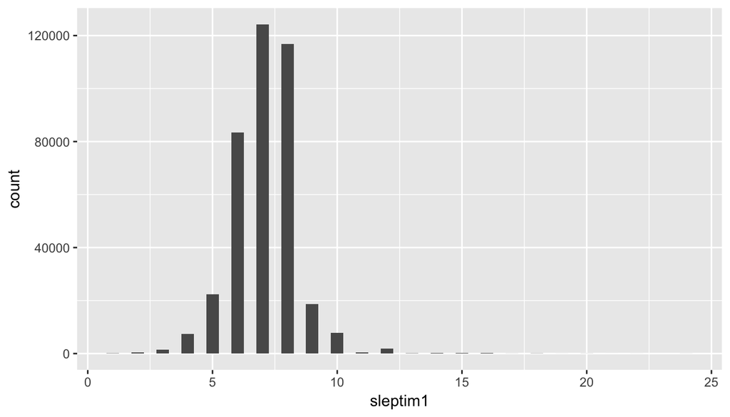

```r
ggplot(data=year2013goodhlth, aes(x=sleptim1))+geom_histogram(binwidth = 0.5)
```

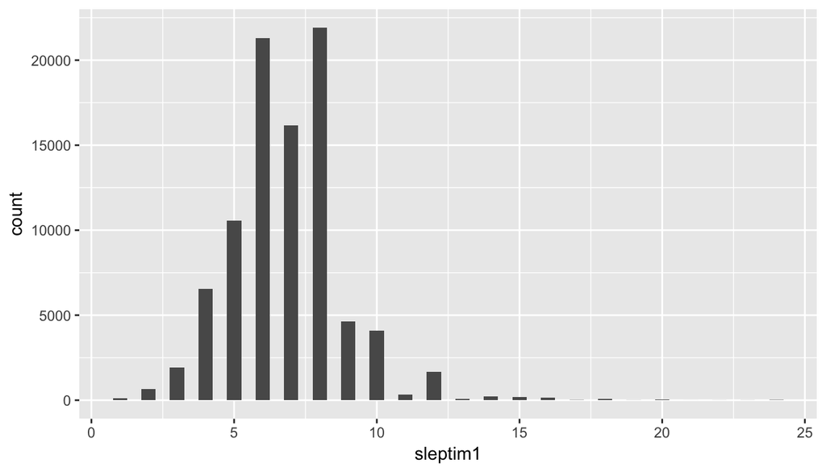

```r
ggplot(data=year2013poorhlth, aes(x=sleptim1))+geom_histogram(binwidth = 0.5)
```

Although some data misses because the “NA” value, it can be ignored because the quantity are not quite large. Both of the two plots show that the most people are tend to sleep 6-8 hours everyday on average. However, the percentage of sleep time of 4 and 5 hours for the poor-health people are obviously higher than those people have a good health.

**Research quesion 2:**

I would like to select the adults who got cell phone-based survey and filter the ones who have been told they have high blood pressure to make a new dataset named as “adultbphigh”.

```r
adultbphigh <- brfss2013 %>%
  filter(!is.na(cadult), bphigh4=="Yes")
```

First step is to get rid of the NA values in “cadult” variable. Then the observations of “Yes” in “bphigh4” are chosen.

Based on the dataset “adultbphigh”, I would like to make a plot to see how the number of people changes as the the household income improves.

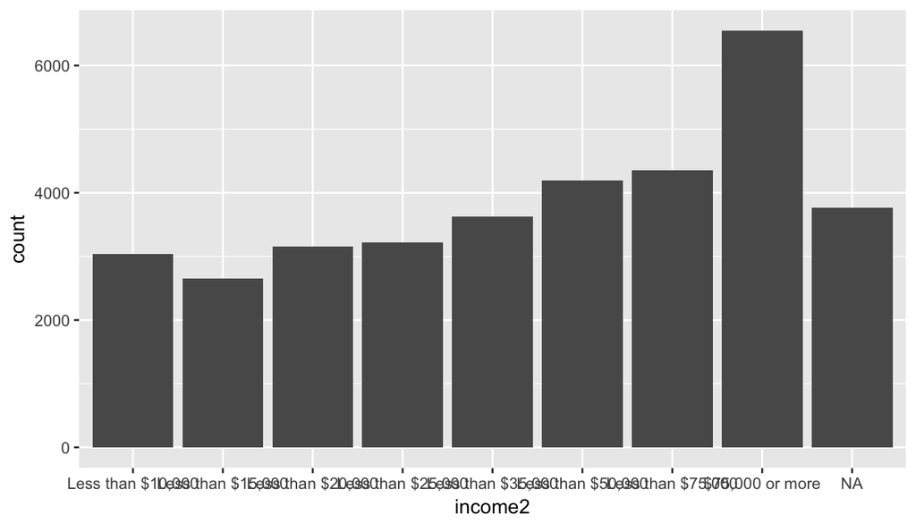

```r
ggplot(data=adultbphigh, aes(x=income2))+geom_bar()
```

**Research quesion 3:**

Firstly, I would like to pick out the data without the students and other meanless obervations.

```r
employenostu <- brfss2013 %>%
  filter(employ1 !="A student", employ1 !="Retired", !is.na(employ1))
```

```r
welleducated <- employenostu %>%
  filter(educa %in% c("Never attended school or only kindergarten", "Grades 1 through 8 (Elementary)","Grades 9 though 11 (Some high school)", "Grade 12 or GED (High school graduate)"))
loweducation <- employenostu %>%
  filter(educa %in% c("College 1 year to 3 years (Some college or technical school)", "College 4 years or more (College graduate)"))
```

Then I would like to see how often do they have a physical exam through plots.

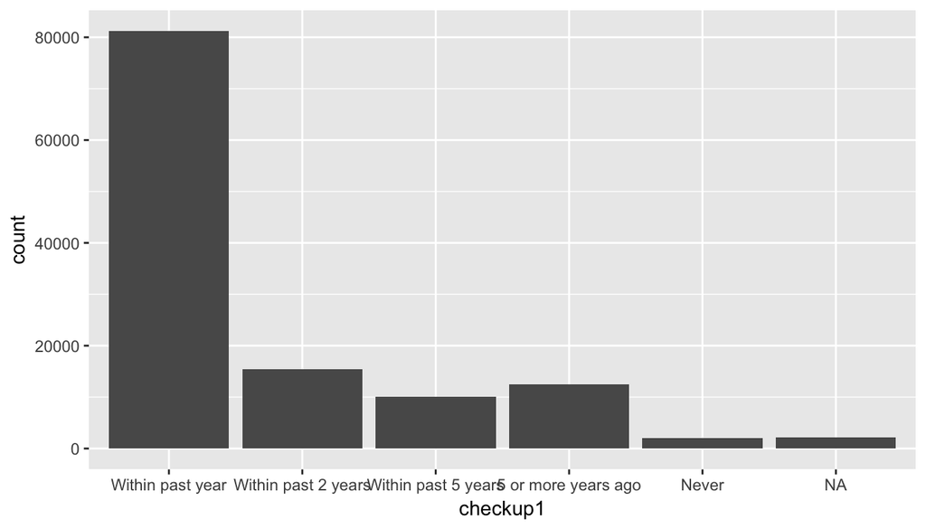

```r
ggplot(data = welleducated, aes(x=checkup1))+geom_bar()
```

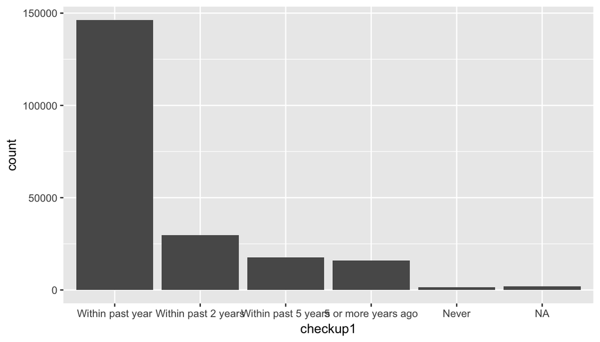

```r
ggplot(data = loweducation, aes(x=checkup1))+geom_bar()
```

Because the two plots are almost the same shape, the education level seems not have association with the frequency of physical exam.